November 19, 202618 min readDraft

# Forgetting as a Test-Time Compute Tax

- Vasilis PapageorgiouUniversity of Wisconsin-Madison

## TL;DR

- In continual learning, "catastrophic forgetting" is usually measured as a **loss of accuracy on old tasks**. For reasoning models, this can hide a practical **test-time cost**: a model can keep its accuracy while spending more tokens per correct answer (including parallel sampling). I therefore measure forgetting in **tokens**, with $\text{cost-of-pass}$, namely the expected number of generated tokens until a correct answer.
- SFT on tool use pays this tax mostly in **failed attempts**, which accuracy sees.
- After 40 RL updates on a logic puzzle, `Qwen3-1.7B` keeps its MATH-500 and HumanEval+ accuracy, but with overlong masking, a common RL training recipe, it pays in **longer attempts**: a correct answer to the median problem costs $\times 1.24$ more tokens ($\times 1.04$–$1.05$ without masking).
- Under a token limit, the same cost shows up as lost accuracy, whose size depends on the limit, while $\text{cost-of-pass}$ ranks the two RL recipes the same way at every limit.

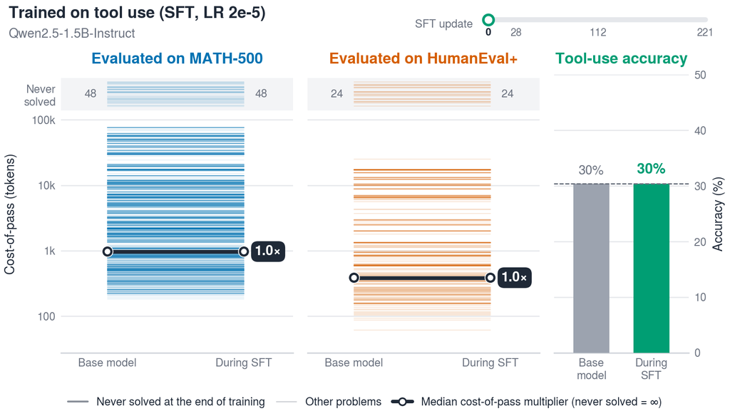

Figure 1. Tokens to a correct answer on MATH-500 and HumanEval+ during SFT on tool use. The bold line shows the median cost multiplier relative to the base model. Each thin line refers to a distinct problem from the corresponding dataset; darker ones mark problems that the final checkpoint never solves.

## Introduction

Despite the fact that **continual learning**'s definition is not really agreed upon, it is widely considered one of the main open challenges in developing AI models that keep adapting beyond deployment. Loosely speaking, a model is able to continually learn if *it can be taught new skills, with minimal degradation in its older ones*, or if *it is easy enough to recover old capabilities with minimal intervention.*

1

M. McCloskey and N. J. Cohen. [*Catastrophic Interference in Connectionist Networks: The Sequential Learning Problem*](https://doi.org/10.1016/S0079-7421%2808%2960536-8). Psychology of Learning and Motivation, 24:109–165, 1989.

2

R. M. French. [*Catastrophic forgetting in connectionist networks*](https://doi.org/10.1016/S1364-6613%2899%2901294-2). Trends in Cognitive Sciences, 3(4):128–135, 1999.

3

H. Zhu et al. [*The Path Not Taken: RLVR Provably Learns Off the Principals*](https://arxiv.org/abs/2511.08567). arXiv:2511.08567, 2025.

4

I. Shenfeld, J. Pari, and P. Agrawal. [*RL's Razor: Why Online Reinforcement Learning Forgets Less*](https://arxiv.org/abs/2509.04259). [ICLR 2026](https://proceedings.iclr.cc/paper_files/paper/2026/hash/618c95f4557c15b253fb0e6f548ea0c0-Abstract-Conference.html).

5

H. Chen, N. Razin, K. R. Narasimhan, and D. Chen. [*Retaining by Doing: The Role of On-Policy Data in Mitigating Forgetting*](https://arxiv.org/abs/2510.18874). [ICML 2026](https://proceedings.mlr.press/v306/chen26do.html).

Historically, one of the terms that first appeared in the literature is **catastrophic interference**<sup>[1]</sup>, later revisited as **catastrophic forgetting**<sup>[2]</sup>, which refers to this very loss of "old" capabilities, under sequential training on new tasks. For LLMs, recent work suggests that *how* we train on the new task matters a lot. Training on off-policy data, as in SFT, can change the model more. Zhu et al.<sup>[3]</sup> find that SFT updates the **principal directions of the weights** and distorts their spectrum. On the other hand, RL with verifiable rewards learns **off those principal directions** and barely changes the spectrum. In addition, it has also been shown that on-policy RL forgets less. Shenfeld et al.<sup>[4]</sup> find that, at similar performance on the new task, RL preserves prior knowledge and capabilities significantly better than SFT, and Chen et al.<sup>[5]</sup> trace this robustness to the use of on-policy data.

In the continual learning literature, forgetting is often measured as a **loss of accuracy** on the old tasks. While running my own experiments, I realized that this can be incomplete, especially for reasoning models. A reasoning model chooses how many tokens to spend before it answers, a behavior that emerges in an **unsupervised manner**. As a result, after trained on a new task, the model may still answer an old question correctly, but may need to generate many more tokens. Accuracy does not see this, yet it is a very practical cost at test time. The model may not only generate more tokens to reach a correct answer, but in addition, as soon as there is an inference token budget, this cost can show up as lost accuracy, i.e., as forgetting in the usual, accuracy-based sense.

6

Qwen Team. [*Qwen3-1.7B* (model card)](https://huggingface.co/Qwen/Qwen3-1.7B). Hugging Face, 2025.

7

H. Lightman et al. [*Let's Verify Step by Step*](https://arxiv.org/abs/2305.20050). [ICLR 2024](https://proceedings.iclr.cc/paper_files/paper/2024/hash/aca97732e30bcf1303bc22ac3924fd16-Abstract-Conference.html). Appendix C describes the 500-problem MATH evaluation split.

8

J. Liu, C. S. Xia, Y. Wang, and L. Zhang. [*Is Your Code Generated by ChatGPT Really Correct? Rigorous Evaluation of Large Language Models for Code Generation*](https://arxiv.org/abs/2305.01210). [NeurIPS 2023](https://proceedings.neurips.cc/paper_files/paper/2023/hash/43e9d647ccd3e4b7b5baab53f0368686-Abstract-Conference.html).

To make this concrete, I trained `Qwen3-1.7B`<sup>[6]</sup> on a logic puzzle with two RL recipes that differ in only **one training option**. Both recipes learn the puzzle, and at a large 32k-token limit, neither loses accuracy on MATH-500<sup>[7]</sup> or HumanEval+<sup>[8]</sup>. However, after training on it, the median MATH-500 problem needs **24% more tokens** to reach a correct answer, and at a 4k-token limit, it looks like it lost ~11 accuracy points on MATH-500.

9

M. H. Erol et al. [*Cost-of-Pass: An Economic Framework for Evaluating Language Models*](https://arxiv.org/abs/2504.13359). [ICLR 2026](https://proceedings.iclr.cc/paper_files/paper/2026/hash/399d54cce01e782192b3d7ecbe607a96-Abstract-Conference.html), Eq. 2.

In this post, I measure forgetting (or the lack thereof) by adapting **$\text{cost-of-pass}$**<sup>[9]</sup> as **the expected number of generated tokens until the model produces a correct answer** (see the cost-of-pass definition). Notice that this includes **parallel sampling**, since I generate multiple rollouts until the first correct one. I first use it in a setting where forgetting is clearly visible in accuracy (SFT), and then in RL, where accuracy on the old tasks does not move, but $\text{cost-of-pass}$ grows by about 25% depending on a single training config.

**Note**: None of the individual pieces is new. The point of this post is what they mean for how we measure forgetting.

## Measuring Forgetting via $\text{cost-of-pass}$

I consider measuring forgetting in terms of **total generated tokens until sampling a correct rollout**. Fix a problem $x$ of verifiable task $\mathcal{T}$. Let $\ell(y)$ be the number of tokens generated in a rollout $y \sim \pi_\theta(\cdot \mid x)$ (thinking and answer), and $p_\theta(x)$ the probability that a rollout is correct. Adapting cost-of-pass<sup>[9]</sup>, which prices a correct solution in dollars, we can count generated tokens as

$$\text{cost-of-pass}_{\theta}(x) := \frac{\mathbb{E}_{y \sim \pi_\theta(\cdot \mid x)}[\ell(y)]}{p_\theta(x)}.$$

Note that if we sample rollouts independently and stop at the first correct one, we need $\frac{1}{p_\theta(x)}$ rollouts on average. Therefore, the expected total number of tokens to be generated is exactly $\text{cost-of-pass}_{\theta}(x)$. In the experiments, I estimate it from $n$ rollouts as total tokens divided by the number of correct ones. As a result, after training on task $\mathcal{B}$, I quantify forgetting on a task $\mathcal{A}$ by the median of $\frac{\text{cost-of-pass}_{\theta_\text{after}}(x)}{\text{cost-of-pass}_{\theta_\text{before}}(x)}$, where $\theta_\text{after}$ and $\theta_\text{before}$ are the weights of the model after and before finetuning on task $\mathcal{B}$, respectively.

## The visible test-time compute tax of SFT

## TL;DR

After SFT on tool use, $\text{cost-of-pass}$ increases on math and code mainly because the model is less likely to produce a correct answer. Part of this drop comes from losing the expected answer format, but accuracy also falls among well-formatted replies. Response length changes too, although here it is pulled towards the fixed lengths of the SFT training data.

10

I. Shenfeld, M. Damani, J. Hübotter, and P. Agrawal. [*Self-Distillation Enables Continual Learning*](https://arxiv.org/abs/2601.19897). [ICML 2026](https://proceedings.mlr.press/v306/shenfeld26a.html).

11

Qwen Team. [*Qwen2.5-1.5B-Instruct* (model card)](https://huggingface.co/Qwen/Qwen2.5-1.5B-Instruct). Hugging Face, 2024.

12

Q. Tang et al. [*ToolAlpaca: Generalized Tool Learning for Language Models with 3000 Simulated Cases*](https://arxiv.org/abs/2306.05301). arXiv:2306.05301, 2023.

For the first experiment, I wanted to replicate a setting where forgetting is cleanly observed, and measure the $\text{cost-of-pass}$ ratio for each tested problem. Therefore, similar to Shenfeld et al.<sup>[10]</sup>, I ran SFT on a small Qwen model (`Qwen2.5-1.5B-Instruct`)<sup>[11]</sup> using a subset of ToolAlpaca<sup>[12]</sup> queries.

In Figure 1, I measure how $\text{cost-of-pass}$ changes on MATH-500 and HumanEval+ during training. We can observe that as SFT on ToolAlpaca progresses, $\text{cost-of-pass}$ on MATH-500 and HumanEval+ increases, with many problems that were previously solvable within our inference budget being lost after SFT.

Below (Figure 2), I decompose the length and probability terms of $\text{cost-of-pass}$ as SFT progresses.

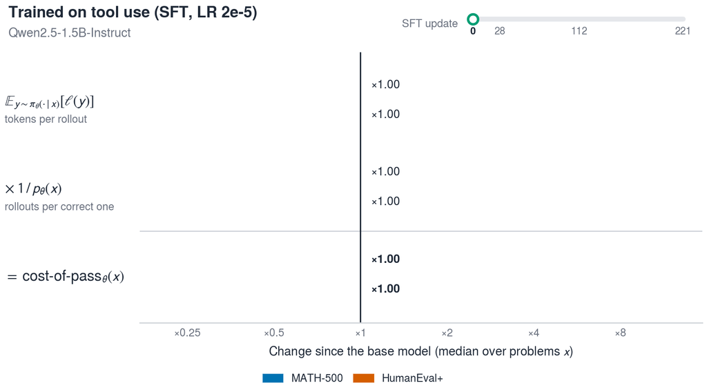

Figure 2. Changes in tokens per rollout, expected rollouts per correct answer, and cost-of-pass during SFT on tool use. Values show median ratios relative to the base model for MATH-500 (blue) and HumanEval+ (orange).

**In this particular setting, the increase in $\text{cost-of-pass}$ comes primarily from the drop in $p_\theta(x)$.** For the median problem, $1/p_\theta(x)$ grows by $\times 6.0$ on MATH-500 and $\times 2.8$ on HumanEval+, while the tokens per rollout shrink on MATH-500 ($\times 0.72$) and grow by only $\times 1.11$ on HumanEval+, against $\times 3.4$ for its $\text{cost-of-pass}$. Analyzing the rollouts, I also observed that part of this drop is due to **formatting**. The model often stops putting its final answer in `\boxed{}` or its code in a code block. The rest is genuinely wrong answers, since accuracy also falls among well-formatted replies.

13

K. Feng et al. [*SciKnowEval: Evaluating Multi-level Scientific Knowledge of Large Language Models*](https://arxiv.org/abs/2406.09098). arXiv:2406.09098, 2024.

**SFT's caveat**. The SFT data that we used for training are off-policy, with a **fixed length**. As a result, SFT pulls the average response length towards the average length of the off-policy rollouts that we are training on. See an example in Figure 3 below, where I train `Qwen2.5-1.5B-Instruct` on ToolAlpaca, as well as a subset of SciKnowEval<sup>[13]</sup> that comprises chemistry problems.

[figure not shown]

Figure 3. Reply lengths on MATH-500 and HumanEval+ during tool-use SFT (left) and chemistry SFT (right). Dotted lines show results for replies that finish. Dashed lines mark the training-output lengths: approximately 71 tokens for tool use and 330 tokens for chemistry.

## The hidden test-time compute tax of RL

## TL;DR

After RL on Knights and Knaves, neither training recipe loses accuracy on math or code at a 32k-token evaluation limit. However, with overlong masking (namely dropping from the loss all the rollouts that hit the cap limit), the expected tokens to a correct answer grow by about 25% for the median problem, compared with only 4–5% without masking. Accuracy alone would have missed this difference in the cost of the old tasks.

In the SFT experiment, accuracy and $\text{cost-of-pass}$ tell a similar story. While tool-use accuracy rises, MATH-500 accuracy falls, and most of the cost increase comes from the $\frac{1}{p_\theta(x)}$ factor. As a result, accuracy alone would have flagged this forgetting. The more interesting case is the opposite one, where training on a new task leaves the accuracy on old tasks intact. RL is the natural place to look for it, since it has been found to forget less than SFT<sup>[4, 5]</sup>.

14

Z. Liu et al. [*Understanding R1-Zero-Like Training: A Critical Perspective*](https://arxiv.org/abs/2503.20783). [COLM 2025](https://openreview.net/forum?id=5PAF7PAY2Y).

15

C. Xie et al. [*On Memorization of Large Language Models in Logical Reasoning*](https://arxiv.org/abs/2410.23123). [IJCNLP–AACL 2025](https://aclanthology.org/2025.ijcnlp-long.148/).

For the next set of experiments, I ran Dr. GRPO<sup>[14]</sup> on `Qwen3-1.7B`. Since `Qwen3` models are heavily post-trained on math and code, I chose to train on a logic puzzle called "Knights and Knaves", generated akin to Xie et al.<sup>[15]</sup>. The task is the following. Everyone on an island is either a knight, who always tells the truth, or a knave, who always lies. The model has to work out who is who from what they say. Each puzzle has exactly one solution, and a reply counts as correct only if it gets every inhabitant's role right. Here's an example:

> A very special island is inhabited only by knights and knaves. Knights always tell the truth, and knaves always lie. You meet 10 inhabitants: Lily, Grace, Uma, Ben, Tara, Paul, Sophia, Noah, Oscar, and Mason. Lily says, "It is false that Oscar is a knight." Grace says, "It is false that Paul is a knave." Uma says, "Mason is a knave." Ben says, "Oscar is a knight." Tara says, "Sophia is a knave if and only if Noah is a knight." Paul says, "If Lily is a knave then Noah is a knave." Sophia says, "Uma is a knave if and only if Mason is a knight." Noah says, "Uma is a knave and Tara is a knight." Oscar says, "Uma is a knight or Mason is a knave." Mason says, "Tara is a knight if and only if Oscar is a knave." So who is a knight and who is a knave?

> List every inhabitant as Name: knight or Name: knave, separated by commas.

**Answer:** Lily: knave, Grace: knight, Uma: knight, Ben: knight, Tara: knight, Paul: knight, Sophia: knight, Noah: knave, Oscar: knight, Mason: knave.

In the runs, puzzles have 10 or 12 inhabitants, and in about half of them the statements nest one level deeper. For example: Uma says, "Hannah is a knave if and only if (Paul is a knight or Rose is a knight)." I train for 40 updates, each on 8 puzzles with 8 rollouts per puzzle, where each training rollouts is capped at 16,384 tokens.

As I previously hinted, I compared **two RL recipes**, who only differ in what happens to a rollout that hits this cap:

16

Q. Yu et al. [*DAPO: An Open-Source LLM Reinforcement Learning System at Scale*](https://arxiv.org/abs/2503.14476). [NeurIPS 2025](https://proceedings.neurips.cc/paper_files/paper/2025/hash/a4277440d50f1f15d2cb4c14f7e0c0d2-Abstract-Conference.html).

- **Unmasked RL** treats rollouts that hit the cap limit as **wrong**; they get reward 0, so the update incentivizes the model to avoid them.
- **Masked RL** leaves rollouts that hit the cap limit **out of the loss**. This is the **overlong filtering** tested in DAPO<sup>[16]</sup>, which masks the loss of truncated samples and, according to its authors, stabilizes training and improves performance. **Important note:** rollouts that hit the limit are used for the **advantage estimation**.

I train two seeds per recipe, and evaluate the base model and the four trained models on held-out puzzles, MATH-500 and HumanEval+, with 8 rollouts per problem, and a large limit of 32k tokens per rollout.

[figure not shown]

Figure 4. Accuracy and cost-of-pass before and after 40 updates of RL on Knights and Knaves (Qwen3-1.7B, 32k-token limit at evaluation). (a) Accuracy on held-out puzzles, MATH-500 and HumanEval+. (b–e) Cost-of-pass per problem on MATH-500 (left) and HumanEval+ (right), after masked (top) and unmasked (bottom) RL. Each thin line is one problem; the grey band holds problems with no correct rollout. Bold line refers to the median cost-of-pass multiplier over the problems the base model solves (never solved count as infinity.

**By accuracy, neither recipe forgets.** Figure 4a shows what an accuracy-based evaluation sees. Both recipes learn the puzzles, and neither loses accuracy on MATH-500 or HumanEval+. If accuracy were the whole story, masked RL would be the recipe to pick, since at our 32k evaluation limit, it learns the new task 7 accuracy points better, at no visible cost on the old ones.

**By $\text{cost-of-pass}$, masked RL pays $\times 1.24$.** The per-problem slopegraphs (Figure 4b–e) tell a different story. After masked RL, the median MATH-500 problem needs $\times 1.24$ the tokens to reach a correct answer, and so does the median HumanEval+ problem. After unmasked RL, however, the multipliers are $\times 1.04$ and $\times 1.05$. That is due to the fact that **masked RL pays in longer rollouts**. After decomposing the $\text{cost-of-pass}$ terms, we can observe that after masked RL, the median MATH-500 problem needs $\times 1.24$ the tokens per rollout and the same number of rollouts ($\times 1.00$), and the same holds on HumanEval+.

**This is the main point of the post**: Accuracy depends only on $p_\theta(x)$, so it is blind to a cost that is paid in longer rollouts.

## When the hidden tax becomes lost accuracy

## TL;DR

Once rollouts are cut at a token limit, the longer rollouts of masked RL turn into wrong ones. As a result, the hidden tax shows up as lost accuracy, whose size depends on the limit, while $\text{cost-of-pass}$ ranks the two recipes the same way at every limit.

Generated token inflation is a caveat in its own right. However, evaluations can come with a token budget limit during test-time. As a result, whether (or how much) a model loses accuracy is inherently tied to its test-time compute profile.

In Figure 5, I take the rollouts of Figure 4 and impose a limit $L$ on the whole reply (thinking and answer). As a result, a rollout longer than $L$ counts as wrong and costs $L$ tokens. With $L$ = 4k, masked RL looks like it lost ~11 accuracy points on MATH-500 and ~8 on HumanEval+. With $L$ = 8k, the gap is 4.7 points on MATH-500 and no longer detectable on HumanEval+. From 16k up, neither recipe is detectably below the base model on either benchmark. In other words, **whether masked RL loses accuracy depends on an evaluation setting**. Unmasked RL, whose rollouts grew much less, loses at most 3.2 points at any of these limits.

**On the other hand, $\text{cost-of-pass}$ does not flip.** At every limit, masked RL needs more tokens per correct answer than the base model, while unmasked RL stays roughly unaffected. As a result, at larger limits, the extra cost is paid in longer rollouts, whereas at tighter limits, the same extra length turns into cut rollouts, and the cost surfaces as lost accuracy. In the shaded region of Figure 5, where accuracy shows no loss for either recipe, $\text{cost-of-pass}$ still separates them.

[figure not shown]

Figure 5. The rollouts of Figure 4, cut at a limit on the whole reply (thinking + answer); a rollout longer than the limit counts as wrong and costs the full limit in tokens. Top: accuracy minus the base model's, in percentage points. Bottom: cost-of-pass relative to the base model, median over the problems the base model solves within the limit.

17

T. Wu, Z. Xu, B. Zhou, and N. Wong. [*The Art of Efficient Reasoning: Data, Reward, and Optimization*](https://arxiv.org/abs/2602.20945). [EMNLP 2026](https://aclanthology.org/2026.emnlp-main.819/).

18

X. Wan, W. Xu, S. Zhao, and M. Sun. [*Mitigating the Length-Scaling Tax with Online Distillation*](https://arxiv.org/abs/2609.38854). arXiv:2609.38854, 2026.

19

M. Luo et al. [*DeepCoder-14B-Preview* (model card)](https://huggingface.co/agentica-org/DeepCoder-14B-Preview). Hugging Face, 2025. See “Iterative Context Lengthening.”

**Related observations.** Of course, none of these pieces is new on its own. Wu et al.<sup>[17]</sup> find that the length bias learned during RL generalizes across domains, and they argue for evaluating across token budgets. Wan et al.<sup>[18]</sup> call excess length on already-solved problems a *length-scaling tax* when it brings little gain in accuracy. And the DeepCoder developers describe the in-domain version of our token-limit effect for their own 14B model, which was trained with DAPO's overlong filtering: its longer responses "are often truncated when the max length is capped at 16K, which can lower its scores"<sup>[19]</sup>. What I add is the forgetting lens: the same length change, on tasks that the model was never trained on, reads as no accuracy loss at a larger limit and as an accuracy loss at a tight one, while $\text{cost-of-pass}$ sees it at both.

## References

1. M. McCloskey and N. J. Cohen. [*Catastrophic Interference in Connectionist Networks: The Sequential Learning Problem*](https://doi.org/10.1016/S0079-7421%2808%2960536-8). Psychology of Learning and Motivation, 24:109–165, 1989. ↩
2. R. M. French. [*Catastrophic forgetting in connectionist networks*](https://doi.org/10.1016/S1364-6613%2899%2901294-2). Trends in Cognitive Sciences, 3(4):128–135, 1999. ↩
3. H. Zhu et al. [*The Path Not Taken: RLVR Provably Learns Off the Principals*](https://arxiv.org/abs/2511.08567). arXiv:2511.08567, 2025. ↩
4. I. Shenfeld, J. Pari, and P. Agrawal. [*RL's Razor: Why Online Reinforcement Learning Forgets Less*](https://arxiv.org/abs/2509.04259). [ICLR 2026](https://proceedings.iclr.cc/paper_files/paper/2026/hash/618c95f4557c15b253fb0e6f548ea0c0-Abstract-Conference.html). ↩ ↩<sup>2</sup>
5. H. Chen, N. Razin, K. R. Narasimhan, and D. Chen. [*Retaining by Doing: The Role of On-Policy Data in Mitigating Forgetting*](https://arxiv.org/abs/2510.18874). [ICML 2026](https://proceedings.mlr.press/v306/chen26do.html). ↩ ↩<sup>2</sup>
6. Qwen Team. [*Qwen3-1.7B* (model card)](https://huggingface.co/Qwen/Qwen3-1.7B). Hugging Face, 2025. ↩
7. H. Lightman et al. [*Let's Verify Step by Step*](https://arxiv.org/abs/2305.20050). [ICLR 2024](https://proceedings.iclr.cc/paper_files/paper/2024/hash/aca97732e30bcf1303bc22ac3924fd16-Abstract-Conference.html). Appendix C describes the 500-problem MATH evaluation split. ↩
8. J. Liu, C. S. Xia, Y. Wang, and L. Zhang. [*Is Your Code Generated by ChatGPT Really Correct? Rigorous Evaluation of Large Language Models for Code Generation*](https://arxiv.org/abs/2305.01210). [NeurIPS 2023](https://proceedings.neurips.cc/paper_files/paper/2023/hash/43e9d647ccd3e4b7b5baab53f0368686-Abstract-Conference.html). ↩
9. M. H. Erol et al. [*Cost-of-Pass: An Economic Framework for Evaluating Language Models*](https://arxiv.org/abs/2504.13359). [ICLR 2026](https://proceedings.iclr.cc/paper_files/paper/2026/hash/399d54cce01e782192b3d7ecbe607a96-Abstract-Conference.html), Eq. 2. ↩ ↩<sup>2</sup>
10. I. Shenfeld, M. Damani, J. Hübotter, and P. Agrawal. [*Self-Distillation Enables Continual Learning*](https://arxiv.org/abs/2601.19897). [ICML 2026](https://proceedings.mlr.press/v306/shenfeld26a.html). ↩
11. Qwen Team. [*Qwen2.5-1.5B-Instruct* (model card)](https://huggingface.co/Qwen/Qwen2.5-1.5B-Instruct). Hugging Face, 2024. ↩
12. Q. Tang et al. [*ToolAlpaca: Generalized Tool Learning for Language Models with 3000 Simulated Cases*](https://arxiv.org/abs/2306.05301). arXiv:2306.05301, 2023. ↩
13. K. Feng et al. [*SciKnowEval: Evaluating Multi-level Scientific Knowledge of Large Language Models*](https://arxiv.org/abs/2406.09098). arXiv:2406.09098, 2024. ↩
14. Z. Liu et al. [*Understanding R1-Zero-Like Training: A Critical Perspective*](https://arxiv.org/abs/2503.20783). [COLM 2025](https://openreview.net/forum?id=5PAF7PAY2Y). ↩
15. C. Xie et al. [*On Memorization of Large Language Models in Logical Reasoning*](https://arxiv.org/abs/2410.23123). [IJCNLP–AACL 2025](https://aclanthology.org/2025.ijcnlp-long.148/). ↩
16. Q. Yu et al. [*DAPO: An Open-Source LLM Reinforcement Learning System at Scale*](https://arxiv.org/abs/2503.14476). [NeurIPS 2025](https://proceedings.neurips.cc/paper_files/paper/2025/hash/a4277440d50f1f15d2cb4c14f7e0c0d2-Abstract-Conference.html). ↩
17. T. Wu, Z. Xu, B. Zhou, and N. Wong. [*The Art of Efficient Reasoning: Data, Reward, and Optimization*](https://arxiv.org/abs/2602.20945). [EMNLP 2026](https://aclanthology.org/2026.emnlp-main.819/). ↩
18. X. Wan, W. Xu, S. Zhao, and M. Sun. [*Mitigating the Length-Scaling Tax with Online Distillation*](https://arxiv.org/abs/2609.38854). arXiv:2609.38854, 2026. ↩
19. M. Luo et al. [*DeepCoder-14B-Preview* (model card)](https://huggingface.co/agentica-org/DeepCoder-14B-Preview). Hugging Face, 2025. See “Iterative Context Lengthening.” ↩